# Homework 10

Sparhawk

2023-04-05

# Homework 10

## Question the First

“Using a for loop, write a function to calculate the number of zeroes in a numeric vector. Before entering the loop, set up a counter variable counter <- 0. Inside the loop, add 1 to counter each time you have a zero in the vector. Finally, use return(counter) for the output.”

```r
zeroCount <- function(x=runif(10)) {
  count <- 0
  for (i in seq_along(x)) {
    if (x[i]==0) {
      count <- count + 1
    }
  }
  return(count)
}

# testing
x <- c(0,0,0,7,4,40,200) # 5 zeros
print(zeroCount(x))
```

```
## [1] 3
```

## Question the Second

“Ok now code that with subsetting to be one line, like a boss”

```r
# FUNCTION: zeroCount2 #########################
# packages: none
# purpose: count the number of zeroes in a vector
# input: a numeric vector
# output: a single integer
#
zeroCount2 <- function(x=runif(10)) {
  count <- length(x[x %% 10 == 0])
  return(count)
}

# testing
print(zeroCount2(x))
```

```
## [1] 5
```

Technically this one only counts numbers like 200 as having one zero, and numbers like 3053 as having none. I could make more complex code to do that, but it would be more than one line (or a VERY long one). The point is; voila, subsetting!

## Question the Third!

“Write a function that takes as input two integers representing the number of rows and columns in a matrix. The output is a matrix of these dimensions in which each element is the product of the row number x the column number.”

```r
# FUNCTION: productMatrix #########################
# packages: none
# purpose: create a matrix of the products of the row and column numbers
# input: the row and column lengths of a matrix
# output: a matrix
#
productMatrix <- function(rows=5, columns=4) {
  m <- matrix(data = NA,nrow=rows,ncol=columns)
  for (i in 1:rows) {
    for (j in 1:columns) {
      m[i,j] <- i*j # these would be a vector[i]*vector[j] if the inputs were vectors
    }
  }
  return(m)
}
# test
print(productMatrix())
```

```
##      [,1] [,2] [,3] [,4]
## [1,]    1    2    3    4
## [2,]    2    4    6    8
## [3,]    3    6    9   12
## [4,]    4    8   12   16
## [5,]    5   10   15   20
```

## Question the Fourfvth!

### a. Make a data frame with 3 groups of data with different means

```r
groups <- c(rep("Control",100),rep("Treatment1",100),rep("Treatment2",100))
data <- c(rnorm(100,mean = 7, sd = 3),
          rnorm(100,mean = 10, sd = 2),
          rnorm(100,mean = 20, sd = 4))
John <- data.frame(groups,data)

head(John)
```

```
##    groups        data
## 1 Control 10.88605174
## 2 Control -0.05678825
## 3 Control  8.30192108
## 4 Control  6.94750293
## 5 Control  4.78332735
## 6 Control  5.14539959
```

### b. Reshuffle the response varaible and calculate the means of each group (in one function)

```r
# FUNCTION: shuffle_and_means #########################
# packages: none
# purpose:
# input:
# output:
#
shuffle_and_means <- function(df=NULL) {
  if(is.null(df)) {stop("gimme a data frame or fugeddaboutit") }

  df[,2] <- sample(df[,2])

  means <- c(mean(df$data[1:100]),mean(df$data[101:200]),mean(df$data[201:300]))
  # wish I remembered how to select by another column's values

  return(means)
}
# test
print(shuffle_and_means(John))
```

```
## [1] 12.09251 13.99564 11.45940
```

### c. use a for loop to repeat shuffle_and_means 100 times in a data frame.

```r
# Data frame for means storage
meanDF <- matrix(data = NA, nrow = 100, ncol = 4, )
meanDF <- data.frame(meanDF)

library(tidyverse)
meanDF <- rename(meanDF,replication=X1, ControlAvg=X2, Treat1Avg=X3, Treat2Avg=X4)

# for loop:
for (i in 1:100) {
  meanDF[i,] <- c(i,shuffle_and_means(John))
}
head(meanDF)
```

```
##   replication ControlAvg Treat1Avg Treat2Avg
## 1           1   12.40661  12.79587  12.34508
## 2           2   13.47410  12.17778  11.89568
## 3           3   11.55719  12.93088  13.05948
## 4           4   13.14287  12.81403  11.59065
## 5           5   11.65542  12.91804  12.97409
## 6           6   11.92218  12.68133  12.94405
```

### d. make a histogram of the reshuffled group means

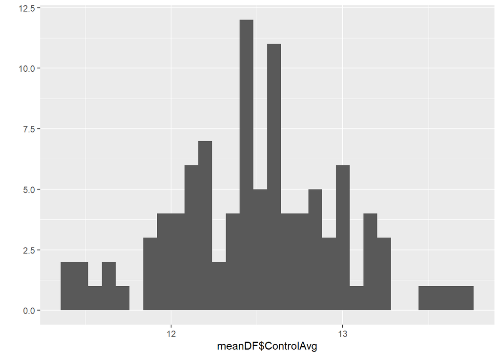

```r
# simple plot
qplot(meanDF$ControlAvg)
```

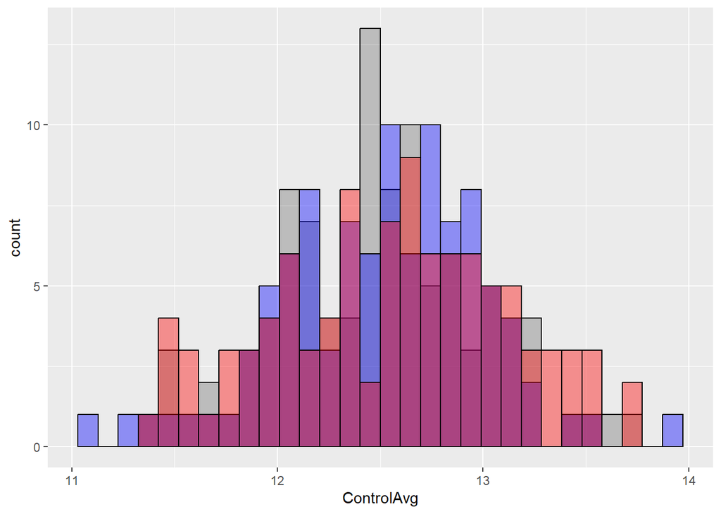

```r
# overlayed histograms
ggplot(meanDF,mapping=aes(x=ControlAvg)) + # this changes the x-axis labels...
  geom_histogram(fill="black", color="black",alpha=0.2) +
  geom_histogram(aes(x=Treat1Avg), fill="blue",color="black",alpha=0.4) +
  geom_histogram(aes(x=Treat2Avg), fill="red",color="black",alpha=0.4)
```

```r
# I'm sure I could spend another 15 minutes looking up how to set up a legend and correct axis labels...
# but you see the gist! Data: graphed.
```